# 12 DECISION TREE MODEL

#### Learning diagram

[figure not shown]

## 12.1 Decision Tree Representation

#### Decision tree representation

- Each internal node tests an attribute
- Each branch corresponds to attribute value
- Each leaf node assigns a classification

  | **Day** | **Outlook** | **Temperature** | **Humidity** | **Wind** | **PlayTennis?** |
  | --- | --- | --- | --- | --- | --- |
  | D1 | Sunny | Hot | High | Weak | No $\ominus$ |
  | D2 | Sunny | Hot | High | Strong | No $\ominus$ |
  | D3 | Overcast | Hot | High | Weak | Yes $\oplus$ |
  | D4 | Rain | Mild | High | Weak | Yes $\oplus$ |
  | D5 | Rain | Cool | Normal | Weak | Yes $\oplus$ |
  | ... | ... | ... | ... | ... | ... |

[figure not shown]

#### When to Consider Decision Trees

- Classification problems
- Instances describable by attribute–value pairs
- Attributes are discrete valued
- Target function is discrete valued

#### Problem Statement

- Hypothesis set $\mathcal{H}$ (**finite set**, there are $2^{2^{n}}$ trees for $n$ binary attributes and binary target)
  - With 6 binary attributes, there are 18,446,744,073,709,551,616 trees

[figure not shown]

- **Task** *T*: to predict $y$ from $\boldsymbol{x}$ by outputting $\hat{y}=h_{T}(\mathbf{x})=T(\boldsymbol{x})$
- **Performance measure** *P*: classification error

## 12.2 Learning Algorithm

#### Which tree is best?

- Which tree would be chosen? if both trees are fitted to $\mathcal{D}=\{(\boldsymbol{x}_{1},y_{1})...(\boldsymbol{x}_{N},y_{N})\}$

[figure not shown]

#### Occam’s Razor

Principle of Occam’s Razor The **simplest** model that fits the data is also the most plausible (prefer the shortest hypothesis that fits the data)

- **Inductive Bias**: Preference for short trees, and for those with high *information gain* attributes near the root

#### Top-Down Algorithm

**function** Decision-Tree-Learning(*examples*, *attributes*)

**if** all *examples* have *the same classification* **then** return *the classification*

**else** **if** *attributes* is $\emptyset$ **then** return Plurality-Value(*examples*)

**else**

$A\leftarrow$ the “best” decision attribute for next $node$

Assign $A$ as decision attribute for $node$

For each value of $A$, create new descendant of $node$

Split training examples to child nodes and **repeat** these steps

[figure not shown]

#### Which attribute is best?

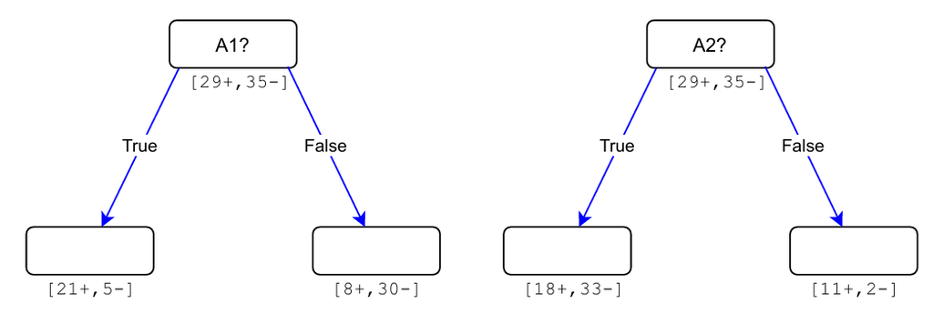

#### Big Picture

[video not shown]

[figure not shown]

### Entropy

#### Information Gain

- $S$ is a sample of training examples
- $p_{\oplus}$ is the proportion of positive examples in $S$
- $p_{\ominus}$ is the proportion of negative examples in $S$
- **Entropy** measures the impurity of $S$
  $$\begin{equation}
  Entropy(S)=-\left(p_{\oplus}\log_{2}p_{\oplus}+p_{\ominus}\log_{2}p_{\ominus}\right)
  \end{equation}$$
- $S$ is a set of items with $C$ classes, and let $\boldsymbol{p}=\{p_{i}\}_{i=1}^{C}$ be the fraction of items labeled with class $i$ in the set.
- **Entropy** measures the impurity of $S$
  $$\begin{equation}
  Entropy(S)=-\sum_{i=1}^{C}p_{i}\log_{2}p_{i}
  \end{equation}$$
- **Average entropy** on attribute $A$
  $$\begin{equation}
  AE(S,A)=\sum_{v\in Values(A)}\frac{|S_{v}|}{|S|}Entropy(S_{v})
  \end{equation}$$
- **Information gain** is expected reduction in entropy on $A$
  $$\begin{equation}
  Gain(S,A)=Entropy(S)-AE(S,A)
  \end{equation}$$
- The best attribute is an attribute that has the highest **information gain**

### Gini

#### Gini index

- **Gini** impurity for a set of items $S$ with $C$ classes, and let $\boldsymbol{p}=\{p_{i}\}_{i=1}^{C}$ be the fraction of items labeled with class $i$ in the set.
  $$\begin{equation}
  GiniImp(S)=1-\sum_{i=1}^{C}p_{i}^{2}
  \end{equation}$$
- **Gini index** on attribute $A$
  $$\begin{equation}
  GiniIndex(S,A)=\sum_{v\in Values(A)}\frac{|S_{v}|}{|S|}GiniImp(S_{v})
  \end{equation}$$

### Misclassification

#### Misclassification index

- **Misclassification impurity index** for a set of items $S$ with $C$ classes, and let $\boldsymbol{p}=\{p_{i}\}_{i=1}^{C}$ be the fraction of items labeled with class $i$ in the set.
  $$\begin{equation}
  MisImp(S)=1-\max\left\{ p_{i}\right\} _{i=1}^{C}
  \end{equation}$$
- **Misclassification index** on attribute $A$
  $$\begin{equation}
  MisIndex(S,A)=\sum_{v\in Values(A)}\frac{|S_{v}|}{|S|}MisImp(S_{v})
  \end{equation}$$

#### Entropy, Gini and Misclassification

[figure not shown]

#### Example 1

- Find decision tree $T$ given the following training data

  | **Day** | **Outlook** | **Temperature** | **Humidity** | **Wind** | **PlayTennis?** |
  | --- | --- | --- | --- | --- | --- |
  | D1 | Sunny | Hot | High | Weak | No |
  | D2 | Sunny | Hot | High | Strong | No |
  | D3 | Overcast | Hot | High | Weak | Yes |
  | D4 | Rain | Mild | High | Weak | Yes |
  | D5 | Rain | Cool | Normal | Weak | Yes |
  | D6 | Rain | Cool | Normal | Strong | No |
  | D7 | Overcast | Cool | Normal | Strong | Yes |
  | D8 | Sunny | Mild | High | Weak | No |
  | D9 | Sunny | Cool | Normal | Weak | Yes |
  | D10 | Rain | Mild | Normal | Weak | Yes |
  | D11 | Sunny | Mild | Normal | Strong | Yes |
  | D12 | Overcast | Mild | High | Strong | Yes |
  | D13 | Overcast | Hot | Normal | Weak | Yes |
  | D14 | Rain | Mild | High | Strong | No |

#### Example 1 - Finding Decision Tree and Converting to Rules

[figure not shown]

| **IF** | $(Outlook=Sunny)\land(Humidity=High)$ | **THEN** | $PlayTennis=No$ |
| --- | --- | --- | --- |
| **ELIF** | $(Outlook=Sunny)\land(Humidity=Normal)$ | **THEN** | $PlayTennis=Yes$ |
| **ELIF** | $Outlook=Overcast$ | **THEN** | $PlayTennis=Yes$ |
| **ELIF** | $(Outlook=Rain)\land(Wind=Strong)$ | **THEN** | $PlayTennis=No$ |
| **ELIF** | $(Outlook=Rain)\land(Wind=Weak)$ | **THEN** | $PlayTennis=Yes$ |
| **ELIF** |  | **THEN** | **failure** |

#### Evaluating Association Rules

An **association rule** is an implication of the form $X\to Y$ or **IF** $X$ **THEN** $Y$

- Support of the association rule
  $$\begin{equation}
  \text{support}(X,Y)=P(X,Y)=\frac{\text{\#count}(X,Y)}{\text{total samples}}
  \end{equation}$$
- Confidence of the association rule
  $$\begin{equation}
  \text{confidence}(X\to Y)=P(Y\mid X)=\frac{\text{\#count}(X,Y)}{\text{\#count}(X)}
  \end{equation}$$

#### Example 2

- Find decision tree $T$ given the following training data

| # | **Input attributes** |  |  |  |  |  |  |  |  |  | **Goal** |
| --- | --- | --- | --- | --- | --- | --- | --- | --- | --- | --- | --- |
|  | **Alt** | **Bar** | **Fri** | **Hun** | **Pat** | **Price** | **Rain** | **Res** | **Type** | **Est** | **Will Wait** |
| 1 | Yes | No | No | Yes | Some | $$$ | No | Yes | French | 0–10 | T |
| 2 | Yes | No | No | Yes | Full | $ | No | No | Thai | 30–60 | F |
| 3 | No | Yes | No | No | Some | $ | No | No | Burger | 0–10 | T |
| 4 | Yes | No | Yes | Yes | Full | $ | Yes | No | Thai | 10–30 | T |
| 5 | Yes | No | Yes | No | Full | $$$ | No | Yes | French | >60 | F |
| 6 | No | Yes | No | Yes | Some | $$ | Yes | Yes | Italian | 0–10 | T |
| 7 | No | Yes | No | No | None | $ | Yes | No | Burger | 0–10 | F |
| 8 | No | No | No | Yes | Some | $$ | Yes | Yes | Thai | 0–10 | T |
| 9 | No | Yes | Yes | No | Full | $ | Yes | No | Burger | >60 | F |
| 10 | Yes | Yes | Yes | Yes | Full | $$$ | No | Yes | Italian | 10–30 | F |
| 11 | No | No | No | No | None | $ | No | No | Thai | 0–10 | F |
| 12 | Yes | Yes | Yes | Yes | Full | $ | No | No | Burger | 30–60 | T |

#### Example 2 - Finding Decision Tree

[figure not shown]

#### Word Example

1. Find decision tree $T$ given the following training datasets
2. Find all **stumps** (decision tree with one node)

   | **#** | **Vị** | **Màu** | **Vỏ** | **Độc tính** |
   | --- | --- | --- | --- | --- |
   | 1 | Ngọt | Đỏ | Nhẵn | Không |
   | 2 | Cay | Đỏ | Nhẵn | Có |
   | 3 | Chua | Vàng | Có gai | Không |
   | 4 | Cay | Vàng | Có gai | Có |
   | 5 | Ngọt | Tím | Có gai | Không |
   | 6 | Chua | Vàng | Nhẵn | Không |
   | 7 | Ngọt | Tím | Nhẵn | Không |
   | 8 | Cay | Tím | Có gai | Có |
   | 9 | Cay | Tím | Có gai | Không |
   | 10 | Cay | Tím | Có gai | Có |
   | 11 | Cay | Vàng | Có gai | Có |

## 12.3 Generalization And Overfitting

#### Overfitting in Decision Tree Learning

[figure not shown]

#### Avoiding Overfitting

How can we avoid overfitting?

- stop growing when data split not statistically significant
- grow full tree, then post-prune

How to select “best” tree:

- Measure performance over training data
- Measure performance over separate validation data set
- Minimize
  $$error(tree)+{\color{green}\lambda}size(tree)$$

## 12.4 Continuous Valued Attributes

#### Continuous Valued Attributes

Create a discrete attribute for continuous variable

- Binary node

  $Temperature>36$ or $Temperature\leq36$
- General node

  $Temperature\in\{(-\infty,0],(0,10],(10,20],(20,\infty)\}$

#### Decision Tree with Continuous Valued Attributes

[figure not shown]

#### Extended Top-Down Algorithm

**procedure** GenerateTree($\mathcal{D}$)

**if** Entropy$(\mathcal{D}) < \epsilon$

Create leaf labelled by majority class in $\mathcal{D}$

**return**

$i$ $\gets$ SplitAttribute($\mathcal{D}$)

**for** each branch of $X_{i}$

Find $\mathcal{D}_{i}$ falling in branch

GenerateTree($\mathcal{D}_{i}$)

**function** SplitAttribute($\mathcal{D}$)

$entropy_{min}$ $\gets$ $\infty$

**for** all attributes $X_{i}$ where $i=1,...,d$

**if** $X_{i}$ is discrete with $n$ values

Split $\mathcal{D}$ into $\mathcal{D}_{1},...,\mathcal{D}_{n}$ by $X_{i}$

$e$ $\gets$ AverageEntropy($\mathcal{D}_{1},...,\mathcal{D}_{n}$)

**if** $e<entropy_{min}$: $entropy_{min}\gets e$, $i_{min}$ $\gets$ $i$

**if** $X_{i}$ is numeric

**for** all possible splits

Split $\mathcal{D}$ into $\mathcal{D}_{1},\mathcal{D}_{2}$ on $X_{i}$

$e$ $\gets$ AverageEntropy($\mathcal{D}_{1},\mathcal{D}_{2}$)

**if** $e<entropy_{min}$: $entropy_{min}\gets e$, $i_{min}\gets i$

**return** $i_{min}$

#### Example 3

- Find decision tree $T$ given the following training data

  | **Day** | **Outlook** | **Temperature** | **Humidity** | **Wind** | **PlayTennis?** |
  | --- | --- | --- | --- | --- | --- |
  | D1 | Sunny | 37 | High | Weak | No |
  | D2 | Sunny | 37 | High | Strong | No |
  | D3 | Overcast | 38 | High | Weak | Yes |
  | D4 | Rain | 28 | High | Weak | Yes |
  | D5 | Rain | 20 | Normal | Weak | Yes |
  | D6 | Rain | 18 | Normal | Strong | No |
  | D7 | Overcast | 19 | Normal | Strong | Yes |
  | D8 | Sunny | 27 | High | Weak | No |
  | D9 | Sunny | 21 | Normal | Weak | Yes |
  | D10 | Rain | 26 | Normal | Weak | Yes |
  | D11 | Sunny | 26 | Normal | Strong | Yes |
  | D12 | Overcast | 27 | High | Strong | Yes |
  | D13 | Overcast | 36 | Normal | Weak | Yes |
  | D14 | Rain | 28 | High | Strong | No |

#### Example 4

- Find decision tree $T$ given the following training data

  | **#** | $x_{1}$ | $x_{2}$ | **label** |
  | --- | --- | --- | --- |
  | A | 0.4 | 0.8 | 1 |
  | B | 0.6 | 0.9 | 1 |
  | C | 0.7 | 0.8 | 1 |
  | D | 0.9 | 0.8 | -1 |
  | E | 0.4 | 0.6 | -1 |
  | F | 0.1 | 0.5 | 1 |
  | G | 0.6 | 0.5 | 1 |
  | H | 0.2 | 0.2 | -1 |
  | I | 0.9 | 0.2 | -1 |
  | J | 0.5 | 0.1 | -1 |

[figure not shown]

## 12.5 Regression Trees

#### Regression Trees

- A **regression tree** is constructed in almost the same manner as a classification tree, except that the impurity measure that is appropriate for classification is replaced by a measure appropriate for regression.

[figure not shown]

#### Loss Function

**Classification**

**Regression**

```
Dataset
```

$\mathcal{D}=\{(x_{1,}y_{1}),...,(x_{n},y_{n}\}$

```
Target
```

$y_{i}$ categorical value

$y_{i}$ real value

Loss function

Entropy

Error

$\overline{y}=\frac{1}{n}\sum_{i=1}^{n}y_{i}$

$e=\frac{1}{n}\sum(y_{i}-\overline{y})^{2}$

$cv=\dfrac{\sqrt{e}}{\overline{y}}$

#### Top-Down Algorithm

**procedure** GenerateTree($\mathcal{D}$)

**if** Error($\mathcal{D}$) < $\epsilon$

Create leaf valued by $\overline{y}$

**return**

$i$ $\gets$ SplitAttribute($\mathcal{D}$)

**for** each branch of $X_{i}$

Find $\mathcal{D}_{i}$ falling in branch

GenerateTree($\mathcal{D}_{i}$)

**function** SplitAttribute($\mathcal{D}$)

$e_{min}$ $\gets$ $\infty$

**for** all attributes $X_{i}$ where $i=1,...,d$

**if** $X_{i}$ is discrete with $n$ values

Split $\mathcal{D}$ into $\mathcal{D}_{1},...,\mathcal{D}_{n}$ by $X_{i}$

$e$ $\gets$ AverageError($\mathcal{D}_{1},...,\mathcal{D}_{n}$)

**if** $e<e_{min}$: $e_{min}\gets e$, $i_{min}$ $\gets$ $i$

**if** $X_{i}$ is numeric

**for** all possible splits

Split $\mathcal{D}$ into $\mathcal{D}_{1},\mathcal{D}_{2}$ on $X_{i}$

$e$ $\gets$ AverageError($\mathcal{D}_{1},\mathcal{D}_{2}$)

**if** $e<e_{min}$: $e_{min}\gets e$, $i_{min}\gets i$

**return** $i_{min}$

#### Example 5

- Find regression tree $T$ given the following training data

  | **Day** | **Outlook** | **Temperature** | **Humidity** | **Wind** | **Play time (m)** |
  | --- | --- | --- | --- | --- | --- |
  | D1 | Rainy | Hot | High | Weak | 26 |
  | D2 | Rainy | Hot | High | Strong | 30 |
  | D3 | Overcast | Hot | High | Weak | 46 |
  | D4 | Sunny | Mild | High | Weak | 46 |
  | D5 | Sunny | Cool | Normal | Weak | 62 |
  | D6 | Sunny | Cool | Normal | Strong | 23 |
  | D7 | Overcast | Cool | Normal | Strong | 43 |
  | D8 | Rainy | Mild | High | Weak | 36 |
  | D9 | Rainy | Cool | Normal | Weak | 38 |
  | D10 | Sunny | Mild | Normal | Weak | 46 |
  | D11 | Rainy | Mild | Normal | Strong | 48 |
  | D12 | Overcast | Mild | High | Strong | 62 |
  | D13 | Overcast | Hot | Normal | Weak | 44 |
  | D14 | Sunny | Mild | High | Strong | 30 |

## 12.6 Multivariate Trees

#### Multivariate Trees

- In the case of a univariate tree, only **one** input dimension **is used** at a split.
- In a multivariate tree, at a decision node, **all** input dimensions **can be used** and thus it is more general.

[figure not shown]

#### Programming Examples

```python
import matplotlib.pyplot as plt
from sklearn.datasets import load_iris
from sklearn.tree import DecisionTreeClassifier, plot_tree

iris = load_iris()
clf = DecisionTreeClassifier(criterion="entropy")
clf.fit(iris.data, iris.target)
plot_tree(clf, filled=True)
plt.show()
```

[figure not shown]

#### A Learning Puzzle Revisited

[figure not shown]

## 12.7 References

[video not shown]